# World Health Data

# Loading of data

```r
whsAnnBdatNum <- read.table("whs2016_AnnexB-data-wo-NAs.txt",sep="\t",header=TRUE,quote="")
summary(whsAnnBdatNum[,c(1,4,7,10,17)])
```

```
##      TOTPOP          LIFEXPB.B       MEDBIRTHS          NEWHIV
##  Min.   :      2   Min.   :50.10   Min.   :  9.00   Min.   : 0.100
##  1st Qu.:   1876   1st Qu.:66.03   1st Qu.: 78.50   1st Qu.: 0.300
##  Median :   8070   Median :72.50   Median : 96.00   Median : 1.563
##  Mean   :  37696   Mean   :71.29   Mean   : 84.28   Mean   : 1.563
##  3rd Qu.:  26413   3rd Qu.:76.38   3rd Qu.: 99.00   3rd Qu.: 1.563
##  Max.   :1383925   Max.   :83.70   Max.   :100.00   Max.   :20.100
##      ALCONS
##  Min.   : 0.000
##  1st Qu.: 2.900
##  Median : 6.085
##  Mean   : 6.085
##  3rd Qu.: 8.700
##  Max.   :17.400
```

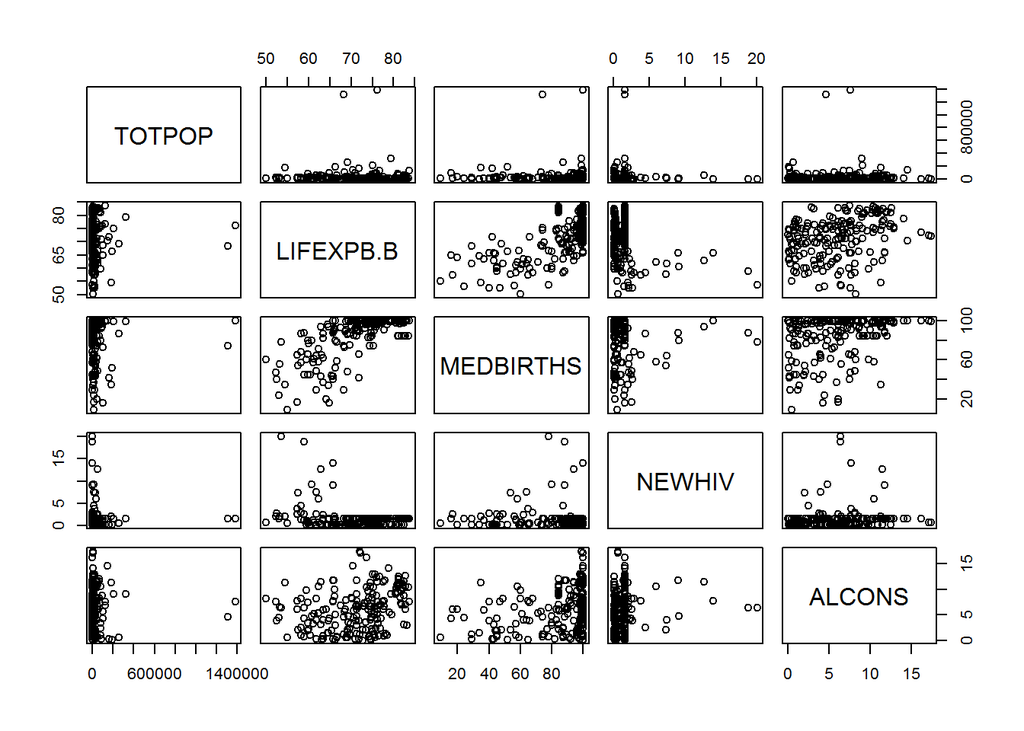

```r
pairs(whsAnnBdatNum[,c(1,4,7,10,17)])
```

# Principal components analysis (PCA)

## Means and Variances of WHS attributes

Comparing means and variances of the *untransformed* attributes in the world health statisics dataset

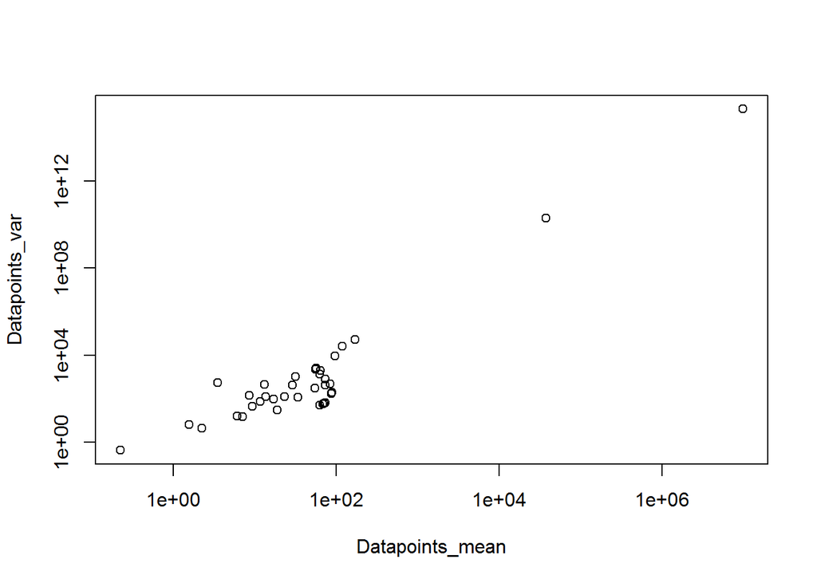

```r
Datapoints_mean = apply(whsAnnBdatNum,2,mean)
Datapoints_var = apply(whsAnnBdatNum,2,var)
plot(Datapoints_mean,Datapoints_var,log="xy")
```

The above graph displays means vs variances. Top 2 points and bottom 1 point have different means and variances as compared to the rest of the dataset.

```r
range(Datapoints_mean, na.rm = FALSE)
```

```
## [1] 2.245902e-01 9.817345e+06
```

```r
range(Datapoints_var,na.rm=FALSE)
```

```
## [1] 4.330536e-01 1.958163e+15
```

The first row above is the range for mean and second column is the range for variance. Variance is very high compared to mean just by looking at the graph it can be said that variance is increasing as mean increases except for few points.

```r
sort(apply(whsAnnBdatNum,2,mean),decreasing = TRUE)
```

```
##     INTINTDS       TOTPOP      MATMORT        TBINC      MALARIA
## 9.817345e+06 3.769596e+04 1.702376e+02 1.187371e+02 9.696442e+01
##    BETTERH2O     HEPBVACC    MEDBIRTHS    LIFEXPB.F  AVEI13HRCCS
## 8.925137e+01 8.772283e+01 8.427624e+01 7.373497e+01 7.318229e+01
##    BETTERSAN    LIFEXPB.B    LIFEXPB.M      MORTAIR    CLEANFUEL
## 7.307143e+01 7.128798e+01 6.887650e+01 6.392500e+01 6.294271e+01
##      HLIFEXP       DRDENS    ADOBIRTHS   MODFAMPLAN       SMOK.M
## 6.280437e+01 5.714431e+01 5.554032e+01 5.470656e+01 3.409766e+01
##    MORTLT5YO     AVEPM2.5     STUNT5YO   PRMORT3070     MORTRAFF
## 3.183505e+01 2.891833e+01 2.315188e+01 1.901628e+01 1.708942e+01
##     NEONMORT     MORTWASH       SMOK.F      SUICIDE     HOMICIDE
## 1.361598e+01 1.328140e+01 1.164922e+01 9.387719e+00 8.659794e+00
##        OW5YO      WAST5YO       ALCONS    DEATHCONF     MORTPOIS
## 7.057480e+00 6.132824e+00 6.085484e+00 3.509302e+00 2.261628e+00
##       NEWHIV      DEATHND
## 1.563303e+00 2.245902e-01
```

The top 2 attributes with highest mean are INTINTDS and TOTPOP.

## PCA on untransformed and scaled WHS data

Obtaining results of principal components analysis of the data (by using `prcomp`)

```r
PCAunscaled = prcomp(whsAnnBdatNum,scale = FALSE)
PCAscaled = prcomp(whsAnnBdatNum,scale = TRUE)
```

Principal component analysis of unscaled data is stored in PCAunscaled and the result of scaled data is stored in PCAscaled.

Generating scree plot of PCA results (by calling `plot` on the result of `prcomp`)

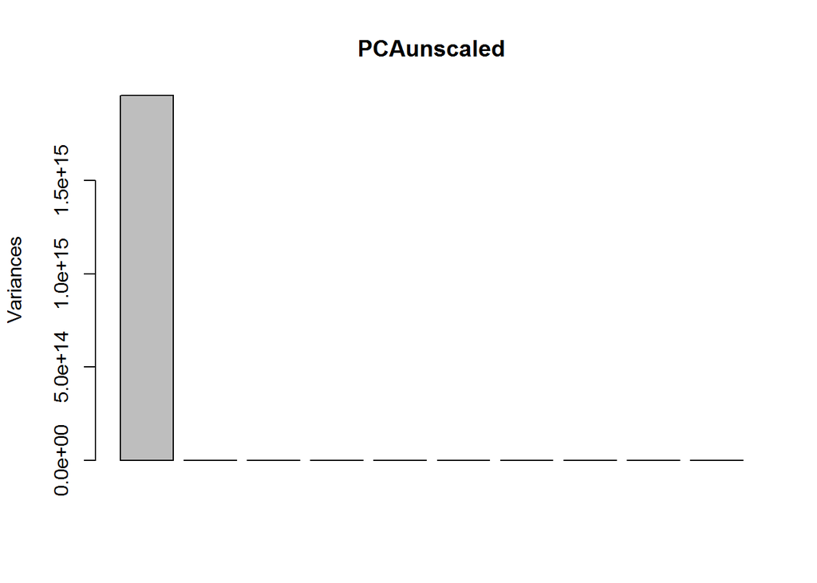

```r
plot(PCAunscaled)
```

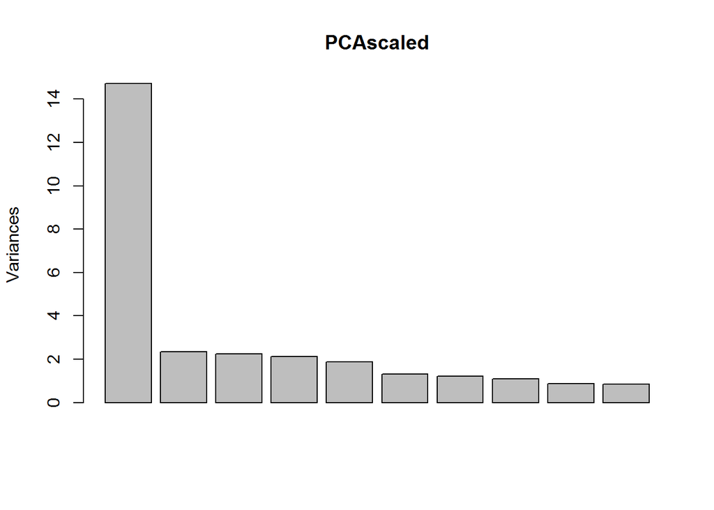

```r
plot(PCAscaled)
```

The above graphs show the scree plot for unscaled and scaled data. In case of unscaled data, the variance is dominated by only one variable to the extent that others are negligible.In case of scaled data, though one variable is dominating other variables contribution is considered towards total varia.

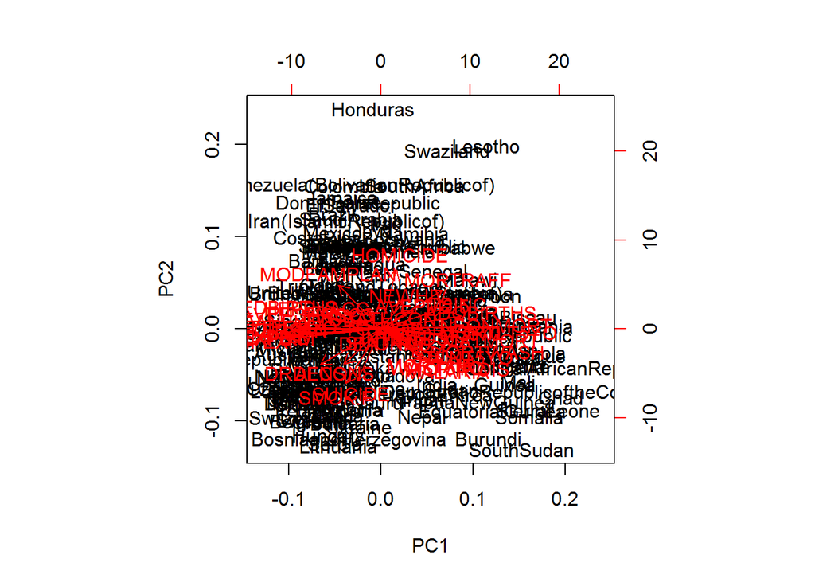

```r
biplot(PCAscaled)
```

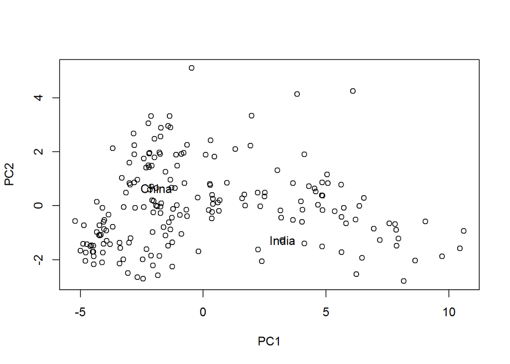

```r
plot(PCAscaled$x[,1:2])
include_list = c("India","China")
s <- PCAscaled$x[include_list,]
text(s[,1:2],labels=rownames(s))
```

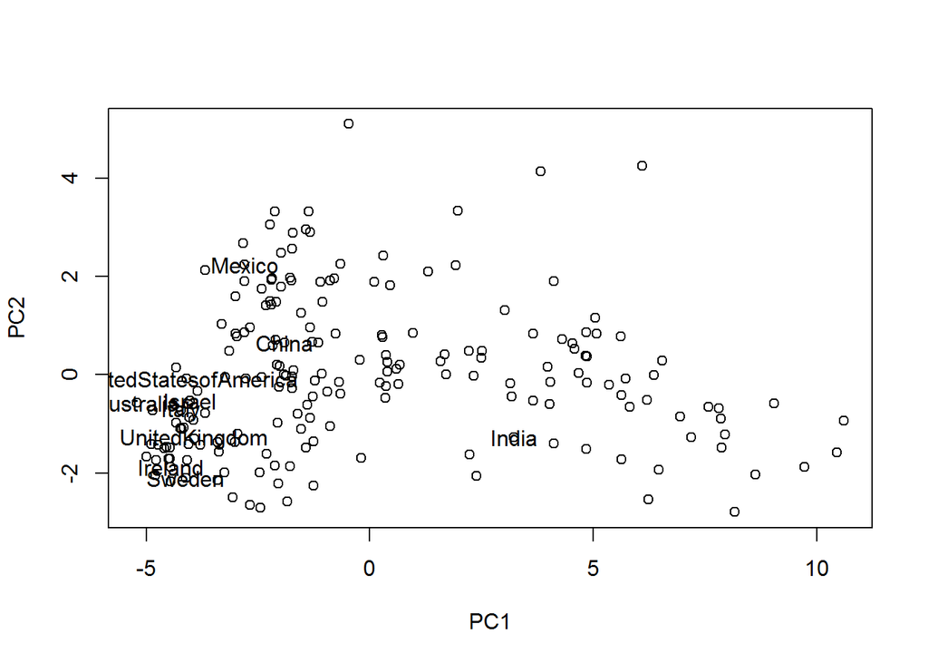

```r
plot(PCAscaled$x[,1:2])
include_list1 = c("UnitedStatesofAmerica", "UnitedKingdom", "China", "India", "Mexico", "Australia", "Israel", "Italy", "Ireland","Sweden")
s1 <- PCAscaled$x[include_list1,]
text(s1[,1:2],labels=rownames(s1))
```

[output not shown]

[output cut: 49 more lines]

[output not shown]

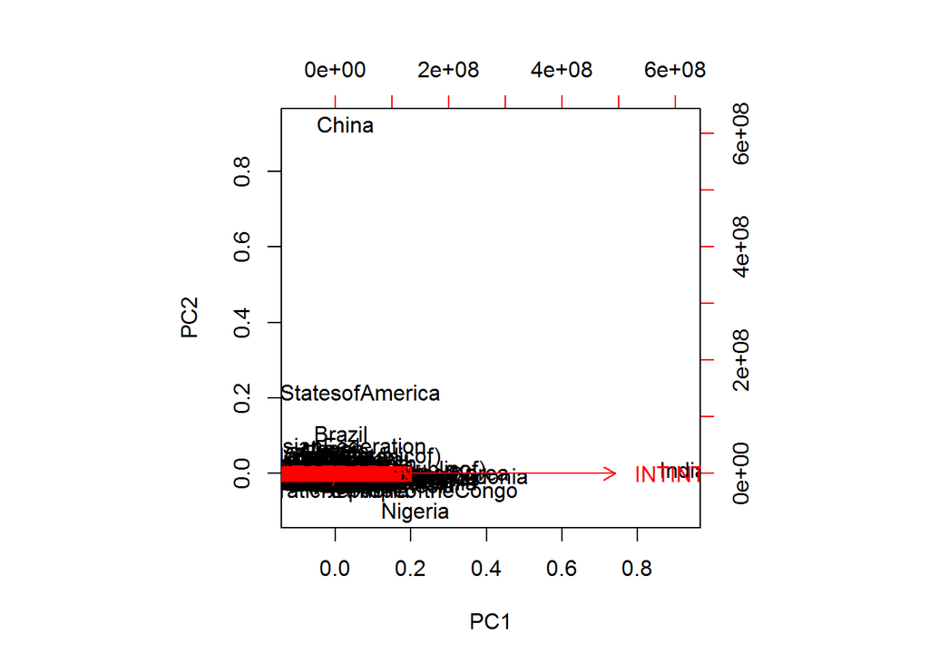

```r
biplot(PCAunscaled)
```

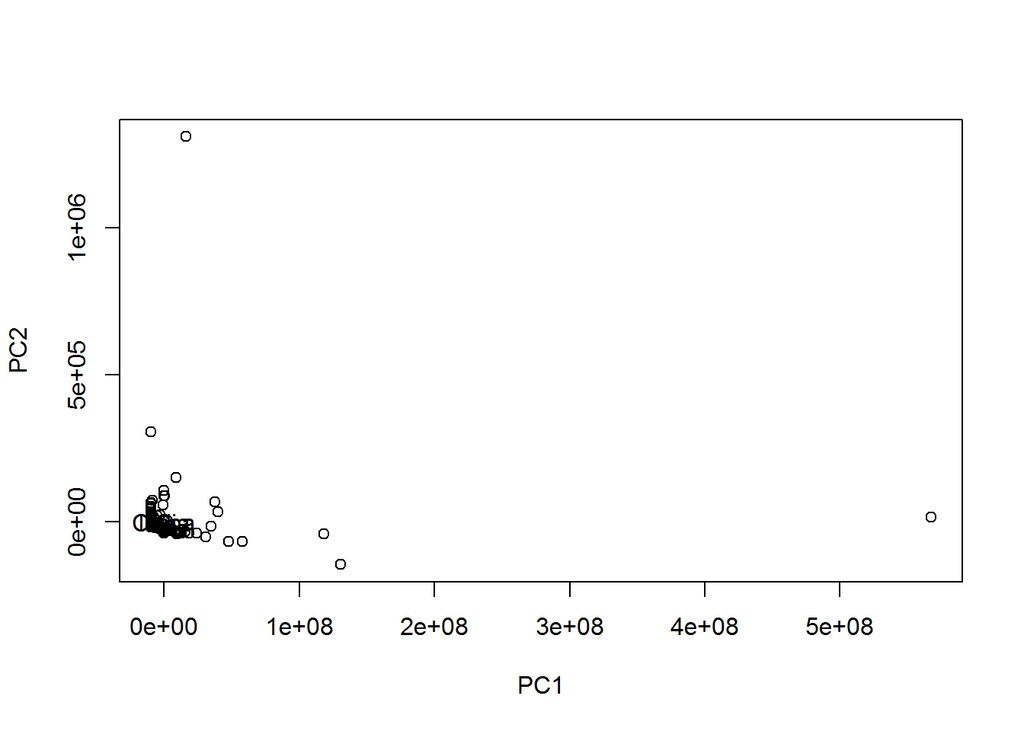

```r
plot(PCAunscaled$x[,1:2])
s <- PCAscaled$x[include_list,]
text(s[,1:2],labels=rownames(s))
```

The above graph shows high number of warnings encountered for unscaled scenario. The text for India and China is also not visible for unscaled data.

```r
PCAscaled$rotation[,1:2]
```

```
##                      PC1          PC2
## TOTPOP       0.004884629  0.006151152
## LIFEXPB.M   -0.243610019 -0.045716073
## LIFEXPB.F   -0.253078454 -0.038740331
## LIFEXPB.B   -0.250555808 -0.044163504
## HLIFEXP     -0.251577110 -0.062282515
## MATMORT      0.232562940 -0.060483184
## MEDBIRTHS   -0.208518840  0.117008115
## MORTLT5YO    0.248011043 -0.017169766
## NEONMORT     0.240496335  0.019160321
## NEWHIV       0.057243300  0.175346962
## TBINC        0.161651357  0.132898176
## MALARIA      0.139047669 -0.223200459
## HEPBVACC    -0.134296639  0.110438222
## INTINTDS     0.050226781 -0.045675955
## PRMORT3070   0.118627350 -0.021286435
## SUICIDE     -0.061782041 -0.338173644
## ALCONS      -0.096091735 -0.231083867
## MORTRAFF     0.161517262  0.258381664
## MODFAMPLAN  -0.110861607  0.290400834
## ADOBIRTHS    0.210892027  0.086389966
## MORTAIR      0.106229940 -0.188556510
## MORTWASH     0.222913074 -0.120690341
## MORTPOIS     0.161571637 -0.210227555
## SMOK.M       0.008364455 -0.071481443
## SMOK.F      -0.093569876 -0.357586945
## DRDENS      -0.159402565 -0.232060185
## AVEI13HRCCS -0.153098290  0.076947082
## STUNT5YO     0.171187159 -0.146795674
## WAST5YO      0.117042181 -0.202157355
## OW5YO       -0.090929875  0.071399248
## BETTERH2O   -0.212469885  0.009767579
## BETTERSAN   -0.230942609 -0.003392105
## CLEANFUEL   -0.224286228  0.038256931
## AVEPM2.5     0.086627851  0.123334535
## DEATHND      0.009362133 -0.075613737
## HOMICIDE     0.040297314  0.391234680
## DEATHCONF    0.017241234  0.055725129
```

The attribute that have largest PC1 is LIFEXPB.F the attribute with largest PC2 is HOMICIDE.

```r
PCAunscaled$rotation[,1:2]
```

```
##                       PC1           PC2
## TOTPOP       2.216726e-03  9.999974e-01
## LIFEXPB.M   -2.241646e-08  1.232984e-05
## LIFEXPB.F   -2.866965e-08  1.270936e-05
## LIFEXPB.B   -2.569642e-08  1.254383e-05
## HLIFEXP     -2.400391e-08  1.193143e-05
## MATMORT      6.035795e-07 -3.598408e-04
## MEDBIRTHS   -8.818667e-08  3.214788e-05
## MORTLT5YO    1.144968e-07 -4.865985e-05
## NEONMORT     5.286241e-08 -1.619241e-05
## NEWHIV      -5.326614e-10 -4.688615e-07
## TBINC        4.634768e-07 -1.389049e-04
## MALARIA      6.078734e-08 -1.665374e-04
## HEPBVACC    -5.116404e-08  1.372377e-05
## INTINTDS     9.999975e-01 -2.216726e-03
## PRMORT3070   1.705779e-08 -2.597847e-06
## SUICIDE      1.208446e-08  1.617659e-06
## ALCONS      -5.139552e-09  2.392531e-06
## MORTRAFF     1.262362e-08 -3.637722e-06
## MODFAMPLAN  -2.125818e-09  2.349719e-05
## ADOBIRTHS    5.677051e-08 -7.290218e-05
## MORTAIR      1.691722e-07  3.096639e-05
## MORTWASH     7.199476e-08 -3.157988e-05
## MORTPOIS     5.358021e-09 -4.700044e-07
## SMOK.M      -1.739610e-08  7.817615e-06
## SMOK.F      -3.289046e-08 -4.406133e-06
## DRDENS      -1.433164e-07  1.411690e-05
## AVEI13HRCCS  3.228241e-08  3.846087e-05
## STUNT5YO     5.439533e-08 -2.235368e-05
## WAST5YO      2.141885e-08 -5.431101e-06
## OW5YO       -1.363438e-08  6.125457e-07
## BETTERH2O   -3.050988e-08  1.930157e-05
## BETTERSAN   -1.282282e-07  3.449176e-05
## CLEANFUEL   -1.493207e-07  3.806764e-05
## AVEPM2.5     1.022098e-07  1.705293e-05
## DEATHND      4.115525e-10 -6.978771e-08
## HOMICIDE    -6.359166e-09 -4.154007e-06
## DEATHCONF   -9.921508e-09 -1.250904e-06
```

The attribute that have largest PC1 is INTINTDS and the attribute that have largest PC2 is TOTPOP which is the same in case of mean vs variance analysis.

```r
pcascaledvar = PCAscaled$sdev[1:5]^2
pcascaledvar
```

```
## [1] 14.721217  2.348165  2.244225  2.125126  1.887558
```

```r
pve = pcascaledvar/sum(pcascaledvar)
pve
```

```
## [1] 0.63109976 0.10066602 0.09621011 0.09110434 0.08091977
```

```r
pcaunscaledvar = PCAunscaled$sdev[1:5]^2
pcaunscaledvar
```

```
## [1] 1.958173e+15 1.032975e+10 6.473395e+04 1.797114e+04 4.582348e+03
```

```r
pve = pcaunscaledvar/sum(pcaunscaledvar)
pve
```

```
## [1] 9.999947e-01 5.275169e-06 3.305817e-11 9.177458e-12 2.340102e-12
```

The first principal component explains 99.9% of the data, the second principal component explains negligible variance in the data.

Now that you have PCA results when applied to untransformed and scaled WHS data, please comment on how do they compare and what is the effect of scaling? What dataset attributes contribute the most (by absolute value) to the top two principal components in each case (untransformed and scaled data)? What are the signs of those contributions? How do you interpret that?

Please note, that the output of `biplot` with almost 200 text labels on it can be pretty busy and tough to read. You can achieve better control when plotting PCA results if instead you plot the first two columns of the `x` attribute in the output of `prcomp` – e.g. `plot(prcomp(USArrests,scale=T)$x[,1:2])`. Then given this plot you can label a subset of countries on the plot by using `text` function in R to add labels at specified positions on the plot. Please feel free to choose several countries of your preference and discuss the results. Alternatively, indicate US, UK, China, India, Mexico, Australia, Israel, Italy, Ireland and Sweden and discuss the results. Where do the countries you have plotted fall in the graph? Considering what you found out about contributions of different attributes to the first two PCs, what do their positions tell us about their (dis-)similarities in terms of associated health statistics?

# K-means clustering

## k-means clusters of different size

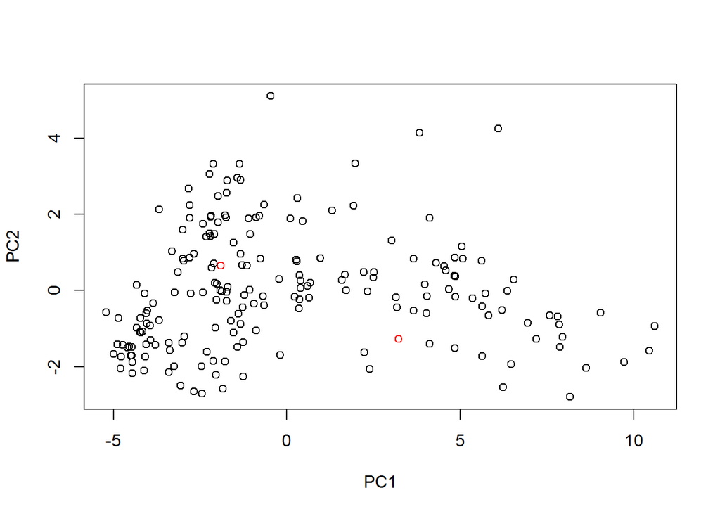

```r
scaledwhs = scale(whsAnnBdatNum)
km = kmeans(scale(whsAnnBdatNum),2)
plot(prcomp(scaledwhs)$x[,1:2],col=km$cluster)
```

```r
sort(km$cluster)
```

```
##                          Afghanistan                              Albania
##                                    1                                    1
##                              Algeria                              Andorra
##                                    1                                    1
##                               Angola                    AntiguaandBarbuda
##                                    1                                    1
##                            Argentina                              Armenia
##                                    1                                    1
##                            Australia                              Austria
##                                    1                                    1
##                           Azerbaijan                              Bahamas
##                                    1                                    1
##                              Bahrain                           Bangladesh
##                                    1                                    1
##                             Barbados                              Belarus
##                                    1                                    1
##                              Belgium                               Belize
##                                    1                                    1
##                                Benin                               Bhutan
##                                    1                                    1
##        Bolivia(PlurinationalStateof)                 BosniaandHerzegovina
##                                    1                                    1
##                             Botswana                               Brazil
##                                    1                                    1
##                     BruneiDarussalam                             Bulgaria
##                                    1                                    1
##                          BurkinaFaso                              Burundi
##                                    1                                    1
##                            CaboVerde                             Cambodia
##                                    1                                    1
##                             Cameroon                               Canada
##                                    1                                    1
##               CentralAfricanRepublic                                 Chad
##                                    1                                    1
##                                Chile                             Colombia
##                                    1                                    1
##                              Comoros                                Congo
##                                    1                                    1
##                          CookIslands                            CostaRica
##                                    1                                    1
```

[output cut: 139 more lines]

```
##                                    1                                    1
##                   UnitedArabEmirates                        UnitedKingdom
##                                    1                                    1
##             UnitedRepublicofTanzania                UnitedStatesofAmerica
##                                    1                                    1
##                              Uruguay                           Uzbekistan
##                                    1                                    1
##                              Vanuatu      Venezuela(BolivarianRepublicof)
##                                    1                                    1
##                              VietNam                                Yemen
##                                    1                                    1
##                               Zambia                             Zimbabwe
##                                    1                                    1
##                                China                                India
##                                    2                                    2
```

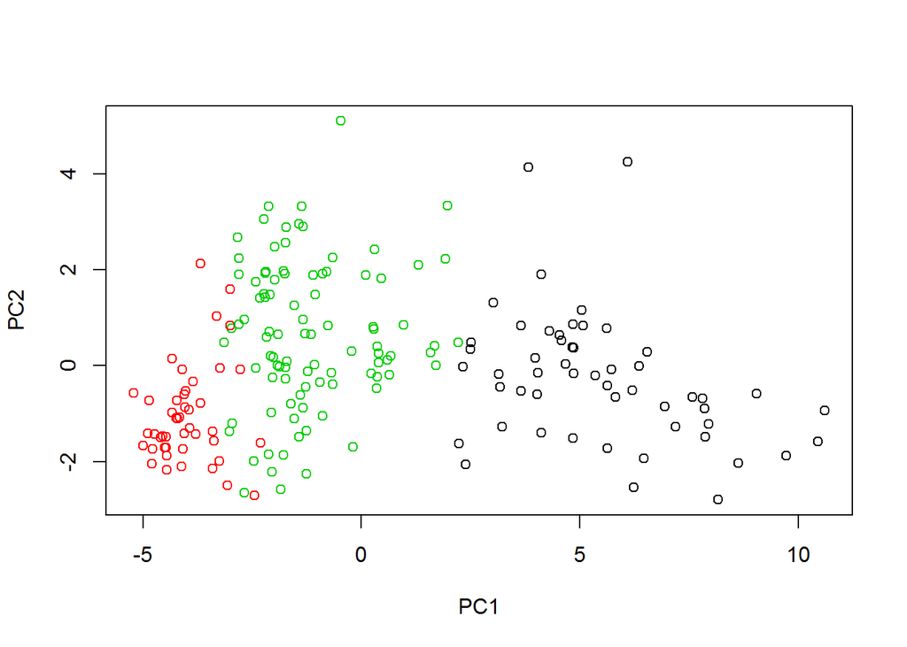

```r
km = kmeans(scale(whsAnnBdatNum),3)
plot(prcomp(scaledwhs)$x[,1:2],col=km$cluster)
```

```r
sort(km$cluster)
```

```
##                          Afghanistan                               Angola
##                                    1                                    1
##                           Bangladesh                                Benin
##                                    1                                    1
##                          BurkinaFaso                              Burundi
##                                    1                                    1
##                             Cameroon               CentralAfricanRepublic
##                                    1                                    1
##                                 Chad                              Comoros
##                                    1                                    1
##                                Congo                         Côted'Ivoire
##                                    1                                    1
##         DemocraticRepublicoftheCongo                             Djibouti
##                                    1                                    1
##                     EquatorialGuinea                              Eritrea
##                                    1                                    1
##                             Ethiopia                                Gabon
##                                    1                                    1
##                               Gambia                                Ghana
##                                    1                                    1
##                               Guinea                        Guinea-Bissau
##                                    1                                    1
##                                Haiti                                India
##                                    1                                    1
##                                Kenya                             Kiribati
##                                    1                                    1
##        LaoPeople'sDemocraticRepublic                              Lesotho
##                                    1                                    1
##                              Liberia                           Madagascar
##                                    1                                    1
##                               Malawi                                 Mali
##                                    1                                    1
##                           Mauritania                           Mozambique
##                                    1                                    1
##                              Myanmar                                Nepal
##                                    1                                    1
##                                Niger                              Nigeria
##                                    1                                    1
##                             Pakistan                       PapuaNewGuinea
##                                    1                                    1
```

[output cut: 139 more lines]

```
##                                    3                                    3
##                             Thailand TheformerYugoslavRepublicofMacedonia
##                                    3                                    3
##                                Tonga                    TrinidadandTobago
##                                    3                                    3
##                              Tunisia                               Turkey
##                                    3                                    3
##                         Turkmenistan                               Tuvalu
##                                    3                                    3
##                              Ukraine                   UnitedArabEmirates
##                                    3                                    3
##                           Uzbekistan                              Vanuatu
##                                    3                                    3
##      Venezuela(BolivarianRepublicof)                              VietNam
##                                    3                                    3
```

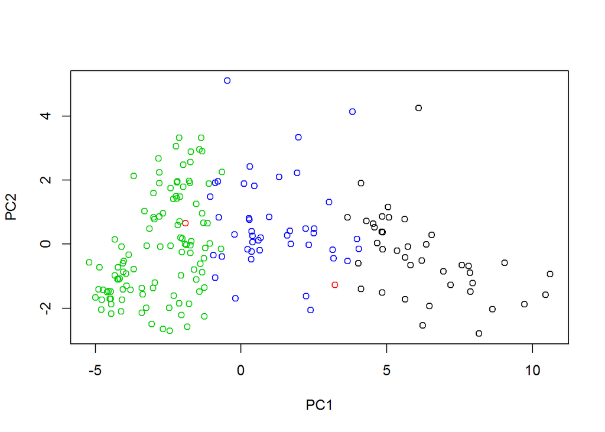

```r
km = kmeans(scale(whsAnnBdatNum),4)
plot(prcomp(scaledwhs)$x[,1:2],col=km$cluster)
```

```r
sort(km$cluster)
```

```
##                          Afghanistan                               Angola
##                                    1                                    1
##                                Benin                          BurkinaFaso
##                                    1                                    1
##                              Burundi                             Cameroon
##                                    1                                    1
##               CentralAfricanRepublic                                 Chad
##                                    1                                    1
##                              Comoros                                Congo
##                                    1                                    1
##                         Côted'Ivoire         DemocraticRepublicoftheCongo
##                                    1                                    1
##                     EquatorialGuinea                              Eritrea
##                                    1                                    1
##                             Ethiopia                               Gambia
##                                    1                                    1
##                                Ghana                               Guinea
##                                    1                                    1
##                        Guinea-Bissau                                Haiti
##                                    1                                    1
##                                Kenya                              Lesotho
##                                    1                                    1
##                              Liberia                           Madagascar
##                                    1                                    1
##                               Malawi                                 Mali
##                                    1                                    1
##                           Mauritania                           Mozambique
##                                    1                                    1
##                                Niger                              Nigeria
##                                    1                                    1
##                       PapuaNewGuinea                          SierraLeone
##                                    1                                    1
##                              Somalia                           SouthSudan
##                                    1                                    1
##                                Sudan                                 Togo
##                                    1                                    1
##                               Uganda             UnitedRepublicofTanzania
##                                    1                                    1
##                               Zambia                             Zimbabwe
##                                    1                                    1
```

[output cut: 139 more lines]

```
##                                    4                                    4
##         SaintVincentandtheGrenadines                                Samoa
##                                    4                                    4
##                   SaoTomeandPrincipe                              Senegal
##                                    4                                    4
##                       SolomonIslands                          SouthAfrica
##                                    4                                    4
##                            Swaziland                   SyrianArabRepublic
##                                    4                                    4
##                           Tajikistan                          Timor-Leste
##                                    4                                    4
##                         Turkmenistan                               Tuvalu
##                                    4                                    4
##                              Vanuatu                                Yemen
##                                    4                                    4
```

## Variability of k-means clustering and effect of `nstart` parameter

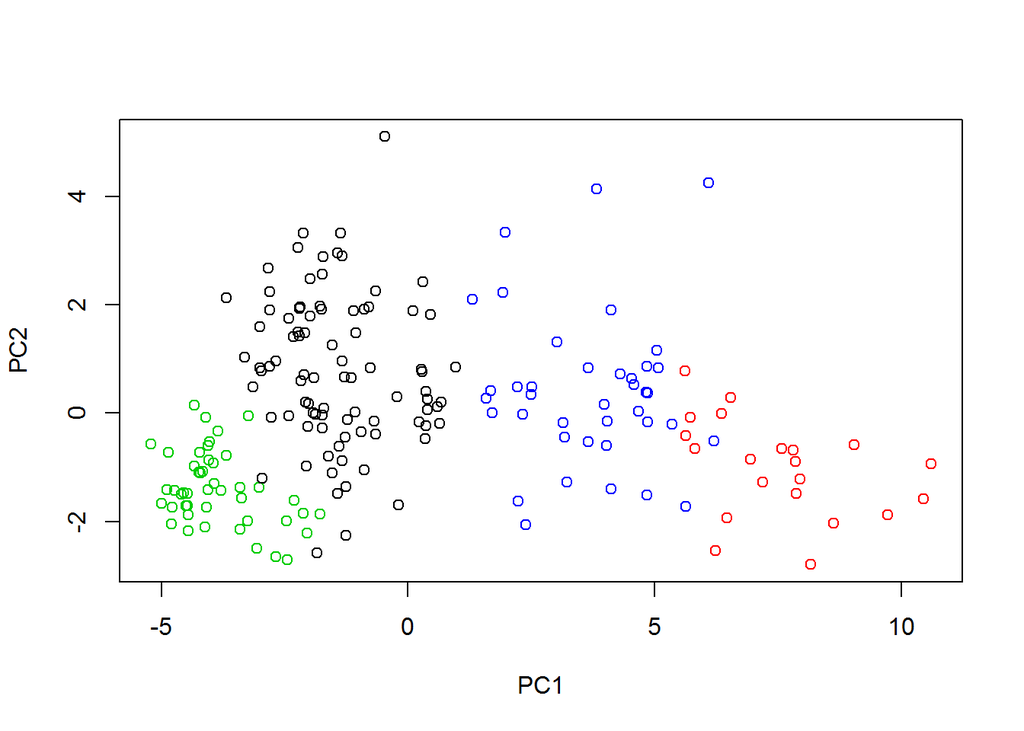

```
## [1] 1.398089
```

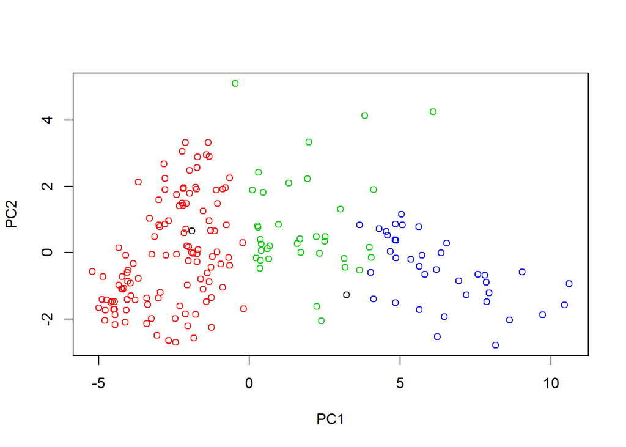

```
## [1] 1.473971
```

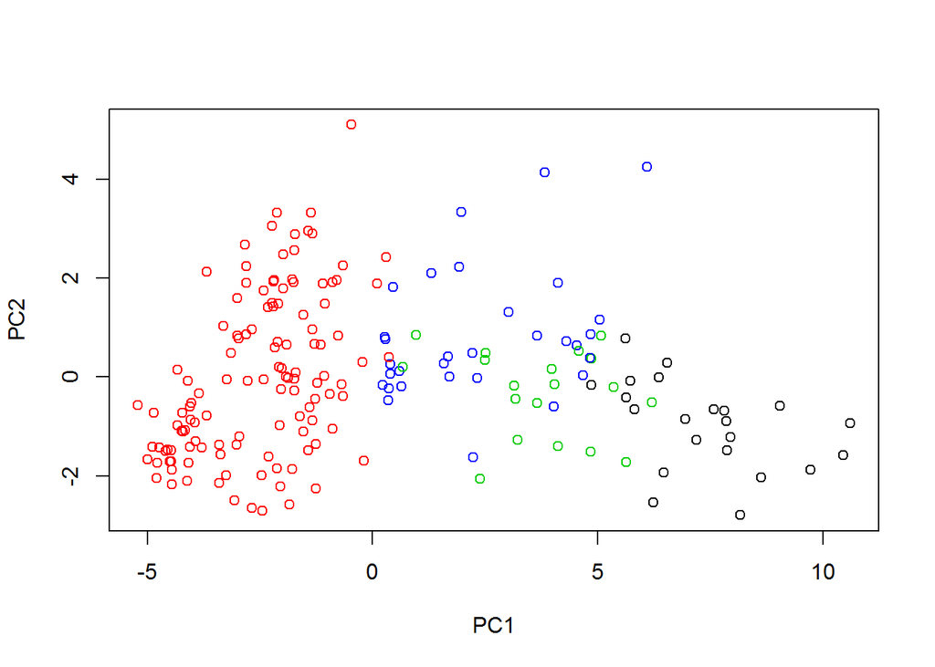

```
## [1] 1.584992
```

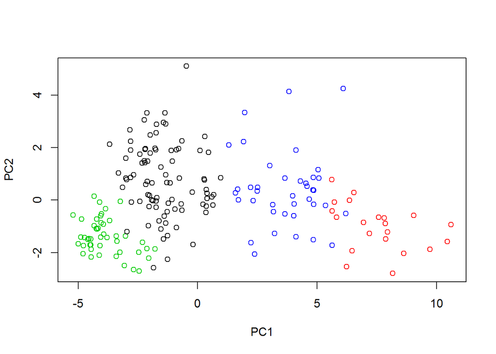

```
## [1] 1.398089
```

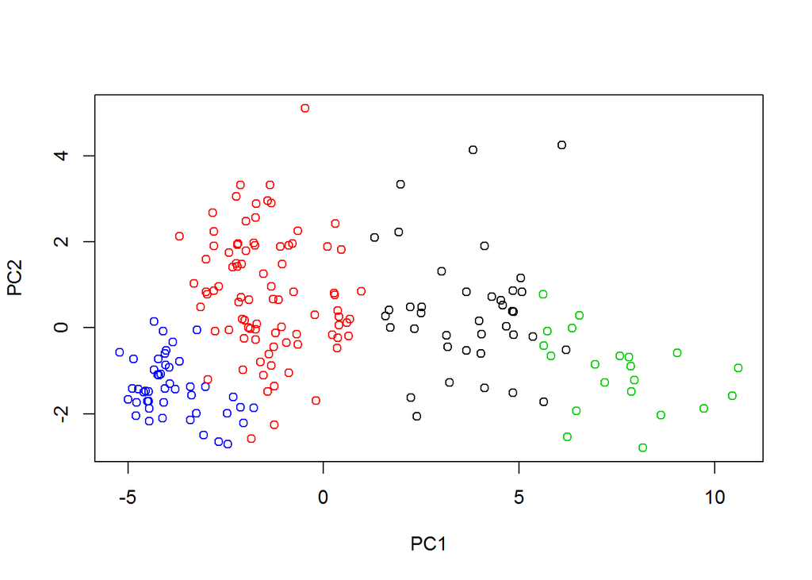

```
## [1] 1.398089
```

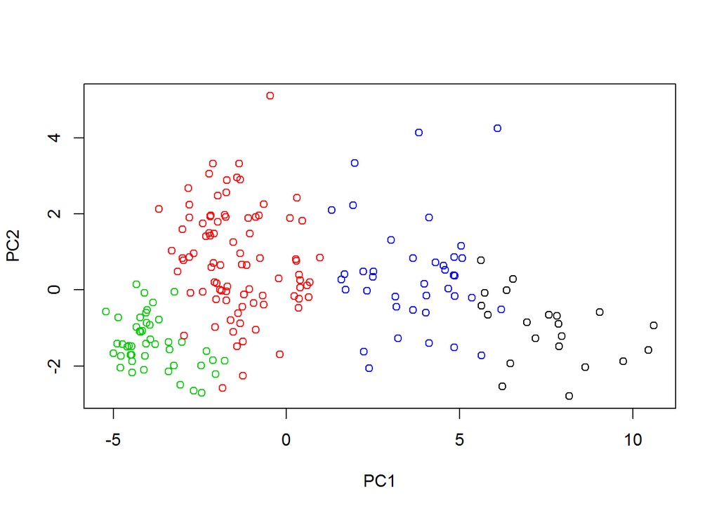

```
## [1] 1.398089
```

```r
nstart = c(1,100)
nseed = c(1,2,3)
for (x in nstart)
{
  for(y in nseed)
  {
    set.seed(y)
    km4=kmeans(scale(whsAnnBdatNum),4,nstart = x)
    plot(prcomp(scaledwhs)$x[,1:2],col=km4$cluster)
    print(km4$tot.withinss/km4$betweenss)
  }
}
```

The ratio of within to between sum-of-squares for default nstart and Seed 1 is 1.39 and for seed 2 is 1.47 and for seed 3 is 1.58. In case of higher than 1 nstart the value of ration of within to between sum of squares is 1.39 for all seeds. The reason for this is when nstart = 100 the start point in changed for each execution and kmeans is executed multiple times and best result is fetched. if nstart is low then undesirable local optimum can be obtained.

# Hierarchical clustering

## Hierachical clustering by different linkages

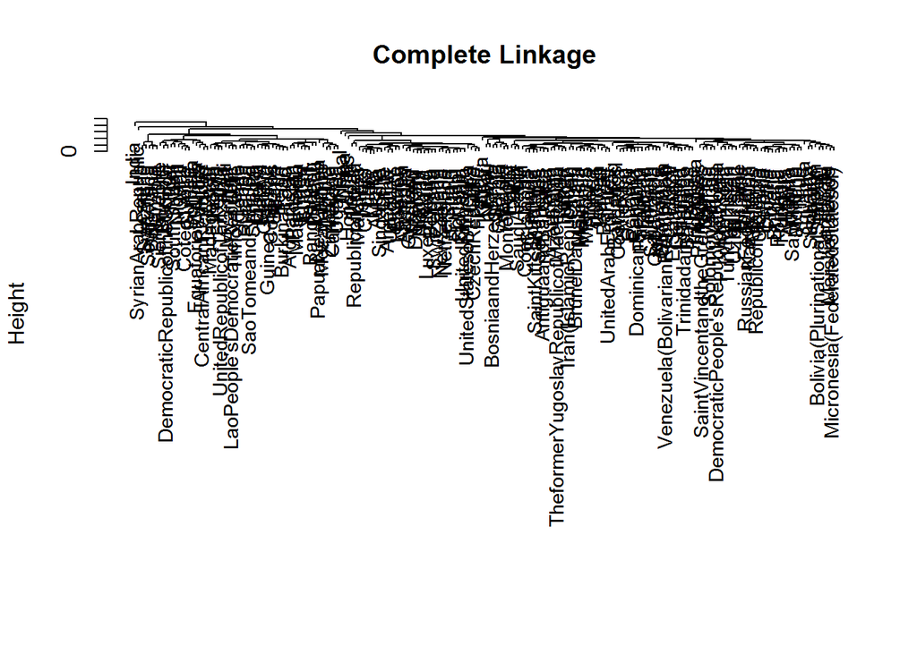

```r
hc.complete =hclust (dist(scaledwhs), method ="complete")
plot(hc.complete ,main ="Complete Linkage", xlab="", sub ="",
cex =.9)
```

[figure not shown]

```r
hc.average =hclust (dist(scaledwhs), method ="average")
plot(hc.complete ,main ="Average Linkage", xlab="", sub ="",
cex =.9)
```

[figure not shown]

```r
hc.single =hclust (dist(scaledwhs), method ="single")
plot(hc.complete ,main ="Single Linkage", xlab="", sub ="",
cex =.9)
```

[figure not shown]

```r
hc.ward =hclust (dist(scaledwhs), method ="ward.D")
plot(hc.complete ,main ="Ward Linkage", xlab="", sub ="",
cex =.9)
```

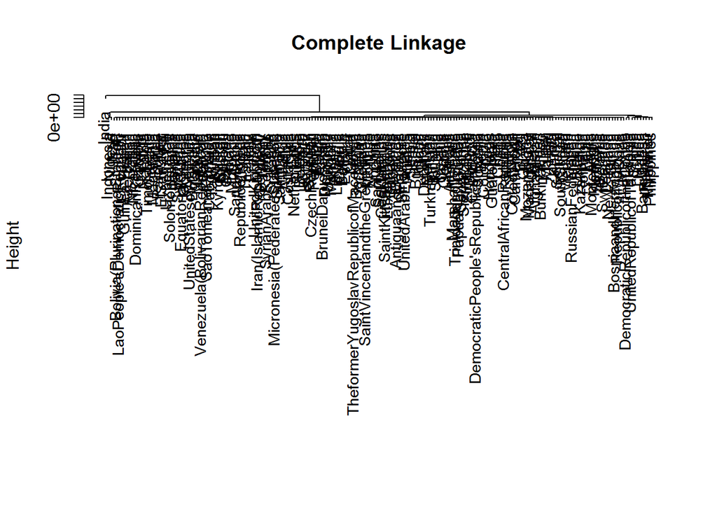

```r
hc.completeunscaled =hclust (dist(whsAnnBdatNum), method ="complete")
plot(hc.completeunscaled ,main ="Complete Linkage", xlab="", sub ="",
cex =.9)
```

Though the hierarchial graph is clumpsy, it can be observed that in scaled attributes scenario the clusters are separated but for unscaled scenario yielded extended clusters hence underlining the importance of scaling before performing clustering analysis.

## Compare k-means and hierarchical clustering

```r
cutree(hc.complete, 4)
```

```
##                          Afghanistan                              Albania
##                                    1                                    2
##                              Algeria                              Andorra
##                                    2                                    2
##                               Angola                    AntiguaandBarbuda
##                                    1                                    2
##                            Argentina                              Armenia
##                                    2                                    2
##                            Australia                              Austria
##                                    2                                    2
##                           Azerbaijan                              Bahamas
##                                    2                                    2
##                              Bahrain                           Bangladesh
##                                    2                                    1
##                             Barbados                              Belarus
##                                    2                                    2
##                              Belgium                               Belize
##                                    2                                    2
##                                Benin                               Bhutan
##                                    1                                    2
##        Bolivia(PlurinationalStateof)                 BosniaandHerzegovina
##                                    2                                    2
##                             Botswana                               Brazil
##                                    1                                    2
##                     BruneiDarussalam                             Bulgaria
##                                    2                                    2
##                          BurkinaFaso                              Burundi
##                                    1                                    1
##                            CaboVerde                             Cambodia
##                                    2                                    2
##                             Cameroon                               Canada
##                                    1                                    2
##               CentralAfricanRepublic                                 Chad
##                                    1                                    1
##                                Chile                                China
##                                    2                                    2
##                             Colombia                              Comoros
##                                    2                                    1
##                                Congo                          CookIslands
##                                    1                                    2
```

[output cut: 139 more lines]

```
##                                    2                                    2
##                               Uganda                              Ukraine
##                                    1                                    2
##                   UnitedArabEmirates                        UnitedKingdom
##                                    2                                    2
##             UnitedRepublicofTanzania                UnitedStatesofAmerica
##                                    1                                    2
##                              Uruguay                           Uzbekistan
##                                    2                                    2
##                              Vanuatu      Venezuela(BolivarianRepublicof)
##                                    2                                    2
##                              VietNam                                Yemen
##                                    2                                    1
##                               Zambia                             Zimbabwe
##                                    1                                    1
```

```r
table(cutree(hc.complete, 4), km4$cluster)
```

```
##
##      1  2  3  4
##   1 21  0  0 34
##   2  0 87 46  4
##   3  0  0  0  1
##   4  0  1  0  0
```